# Beautiful Music: Symbolic Generation on the Nottingham Folk Corpus

## 3.3 Evaluation — Code & results

The OA metric is a kernel-density overlap, computed per feature against the oracle and averaged:

```
def overlapping_area(real_vals, gen_vals, n=1000):
    x = np.linspace(lo, hi, n); step = (hi-lo)/n
    return np.clip(np.sum(np.minimum(gaussian_kde(real)(x),
                                     gaussian_kde(gen)(x))) * step, 0, 1)
```

```python
# Full Task 1 results table (medium run). NLL/PPL are blank for models where we do not
# compute a clean per-token likelihood (GPT-2 sub-words; pretrained TunesFormer/MelodyT5).
cols = ["model", "grammar_validity", "scale_consistency_mean",
        "OA_overall", "test_nll", "test_ppl", "n_midi_valid"]
t1[cols].round(3)
```

|  | model | grammar_validity | scale_consistency_mean | OA_overall | test_nll | test_ppl | n_midi_valid |
| --- | --- | --- | --- | --- | --- | --- | --- |
| 0 | Real_TestSet (Oracle) | 1.00 | 0.985 | 1.000 | NaN | NaN | 98 |
| 1 | Markov_Markov_k3_a0.1 | 0.80 | 0.878 | 0.257 | 1.490 | 4.436 | 20 |
| 2 | Markov_k2_a0.2 | 0.20 | 0.895 | 0.271 | 1.590 | 4.903 | 20 |
| 3 | CharLSTM | 1.00 | 0.865 | 0.210 | 0.996 | 2.708 | 20 |
| 4 | GPT2_FT | 1.00 | 0.929 | 0.124 | NaN | NaN | 19 |
| 5 | TunesFormer | 1.00 | 1.000 | 0.102 | NaN | NaN | 20 |
| 6 | MelodyT5 | 0.95 | 0.997 | 0.302 | NaN | NaN | 19 |

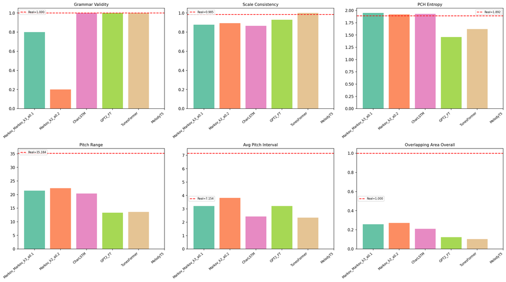

```python
# Visual comparison of generated models against the real-test-set oracle across feature metrics.
display(Image("task1_comparison.png"))
```

## 4 Task 1 — Related Work

- **Boulanger-Lewandowski, Bengio & Vincent (2012)** established Nottingham as a symbolic-music benchmark, reporting log-likelihood for N-grams, RNNs, and RNN-RBM/NADE models on an 88-dimensional **piano-roll** representation. Our likelihoods are *not directly comparable* (we model **ABC characters**, not piano-roll frames), so we use their numbers as **historical context** and as justification for reporting NLL/perplexity — not as a leaderboard.
- **Sturm et al. (2016), "FolkRNN"** showed that ABC folk tunes can be modelled as text with a char-level LSTM — direct precedent for our CharLSTM.
- **Geerlings & Meroño-Peñuela (2020)** fine-tuned GPT-2 on ABC notation, motivating our GPT-2 baseline. **Wu et al. (2023, TunesFormer; 2024, MelodyT5)** are ABC-native Transformers with bar-patching/control codes; we run their published models as strong references.
- **Yang & Lerch (2018)** motivate objective symbolic-music metrics (pitch/rhythm distributions, overlap-style comparison), which our pitch/rhythm/OA metrics follow.

**How our results compare.** Consistent with FolkRNN, a learned recurrent model beats a fixed N-gram on held-out likelihood; consistent with the metric literature, no generator matches the oracle distribution, and likelihood ranking ≠ distribution-matching ranking.

# TASK 2 — Symbolic, Conditioned Generation

**Goal.** Generate music *conditionally on an input*. Our pipeline: `input melody → detect style (classifier) → generate a new continuation conditioned on (detected style + seed bars)`. This satisfies the "conditioned generation given some input" requirement: the input supplies **two** conditions — a **style label** and an **opening seed** — and the model produces *new* notes rather than copying the input.

## 1.1 Data — Context

Same **Nottingham ABC** corpus as Task 1, but here we exploit a free supervision signal: in the JukeDeck release the **file name is the style label** (`jigs.abc`, `reels.abc`, `hornpipes.abc`, `waltzes.abc`). We restrict to the **four styles with enough data** — *jig* (6/8), *reel* (4/4), *hornpipe* (4/4, dotted feel), *waltz* (3/4) — and skip rare classes (slip jigs, morris) that are too small to train/evaluate on.

## 1.2 Data — Discussion (pre-processing)

- **Tune parsing → `Tune` objects** with parsed header (`meter`, `unit`, `key`) and a list of **bars** (`split_bars` on `|`). Chords are stripped as in Task 1.
- **Conditional examples.** For each tune we form `header + seed_bars + <SEED_END> + continuation_bars`. The first few bars are the **seed**; the rest is the **target continuation** the generators must learn to produce.
- **Classifier features.** Each bar is turned into a **35-dim feature vector** — pitch-class distribution (12), key one-hot (12), meter one-hot (4), plus note-count, pitch-range, unique-notes, sinusoidal **bar-position**, rhythmic density, and interval variance — so the classifier sees melodic + metric + rhythmic cues, not raw text.
- **Class imbalance is real and reported:** jigs/reels are plentiful while hornpipes/waltzes are scarce (reflected in the per-style test counts below), which we account for when reading per-style accuracy.

## 1.3 Data — Code & statistics

```
# code/task2_conditional_generation/run_task2.py  -- per-bar feature vector (35-dim)
def extract_bar_features(bar, key, meter, bar_idx=0, total_bars=1):
    return np.concatenate([
        pc_dist,                       # 12  pitch-class distribution (duration-weighted)
        key_vec,                       # 12  key root one-hot
        meter_vec,                     #  4  meter one-hot (6/8, 4/4, 3/4, other)
        [note_count, pitch_range, unique_notes,
         sin_pos, cos_pos,             #     cyclic bar position within the tune
         rhythm_density, interval_var]
    ])
```

```python
# Per-style evaluation counts (medium run) -- note the jig/reel vs hornpipe/waltz imbalance.
t2 = pd.read_csv("t2_metrics.csv")
counts = t2[t2["model"] == "markov_baseline"][["style", "n_generated"]].set_index("style")
counts.columns = ["# evaluated tunes"]
counts.T
```

| style | jig | reel | hornpipe | waltz |
| --- | --- | --- | --- | --- |
| # evaluated tunes | 20 | 20 | 6 | 5 |

## 2.1 Modeling — Context

**ML formulation (two stages).**

1. **Style detector** $g$: maps an input tune to one of 4 styles. Trained with cross-entropy on the bar-feature sequences; inputs = features, output = style label. We train **two** detectors (an **MLP** on song-level mean/std features and a **bidirectional GRU** on the bar sequence) and keep the better one on the held-out test set.
2. **Conditional generator** $p(\text{continuation}\mid \text{style}, \text{seed})$: an autoregressive model whose prompt is `header + style token + seed + <SEED_END>`; it then decodes only the **new** continuation tokens. Objective = NLL of the continuation; we report perplexity where it is well-defined.

We implement four generators of increasing structure: **per-style Markov**, **scratch Transformer**, **GPT-2 fine-tuned**, and a **style-conditioned GRU-VAE**.

## 2.2 Modeling — Discussion (advantages / disadvantages)

| Generator | Pros | Cons |
| --- | --- | --- |
| **Per-style Markov** | Trivial, fast; competitive on style control; gives a real PPL | Local only; cannot plan phrase structure |
| **Scratch Transformer** | Causal self-attention; **lowest perplexity**; trained fully by us | Needs more data than we have for the rare styles |
| **GPT-2 fine-tuned** | Pretrained prior → **best style accuracy & composite**; very fluent | No clean PPL here; sub-word tokens not music-aware |
| **Style-conditioned GRU-VAE** | Latent `z` + style embedding → **best cross-style diversity**; controllable | Reconstruction blur; weaker exact likelihood |

Trade-off summary: GPT-2 wins on *obeying the condition*, the Transformer wins on *likelihood*, and the VAE wins on *diversity* — there is no universal winner, which is the point.

## 2.3 Modeling — Code (architectures & the conditioning mechanism)

The **conditioning** is explicit: the prompt carries a style token + the seed, and only tokens *after* the seed are returned as the generated continuation:

```
class TransformerGenerator:
    def generate_continuation(self, tune, style):
        ids = prompt_ids(tune, style, self.vocab, max_len)   # header + STYLE + seed + <SEED_END>
        generated = ids.clone()
        for _ in range(max_new_tokens):                      # causal top-k sampling
            logits = self.model(generated)[0, -1] / 0.95
            ...
        return self.vocab.decode_chars(generated[0, ids.shape[1]:])   # ONLY the new tokens
```

Scratch Transformer (decoder-style, causal mask) and the style-VAE (the style id is embedded and concatenated to the decoder input at every step, alongside the latent `z`):

```
class ScratchTransformer(nn.Module):           # token+pos embed -> causal TransformerEncoder -> head
    def forward(self, ids):
        x = self.tok(ids) + self.pos(pos)
        mask = torch.triu(torch.ones(L, L, dtype=bool), 1)     # causal
        return self.head(self.ln(self.blocks(x, mask=mask)))

class StyleVAE(nn.Module):                      # GRU encoder -> (mu, logvar) -> z; GRU decoder
    def forward(self, ids):
        mu, logvar = self.encode(ids); z = mu + randn_like(std)*std
        s = self.style_emb(ids[:,1])            # <-- style conditioning
        out,_ = self.dec(cat([emb, z_rep, s_rep], -1))
        return self.head(out), mu, logvar
```

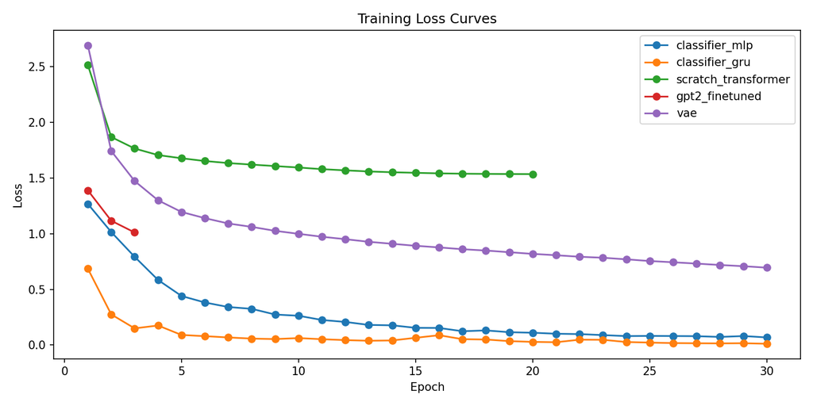

```python
# Generator + classifier training loss curves (medium run).
display(Image("training_loss_curves.png"))
```

## 3.1 Evaluation — Context

A *good* conditioned output must (a) **obey the condition** and (b) **be a valid, varied tune**. We therefore evaluate condition-following directly:

- **Style accuracy** — fraction of generations the **classifier** labels as the *target* style (the classifier acts as an automatic judge of whether the condition was honoured).
- **Meter consistency / seed-key consistency / structural validity** — does the output keep the style's expected meter (jig 6/8, reel/hornpipe 4/4, waltz 3/4), preserve the seed's key, and contain bar/repeat structure?
- **Intra- & cross-style diversity** — normalised edit distance among outputs (anti-copying) and between styles (does the model actually differentiate styles?).
- **Pitch-range naturalness** and **valid-MIDI rate** as sanity floors.
- **Perplexity** where well-defined (Markov, scratch Transformer).

**Objective vs. subjective:** perplexity rewards predictable continuations, but a perfectly predictable tune is boring — so we pair it with diversity and with style accuracy (a *semantic* target), and keep narrated audio reels for human listening.

## 3.3 Evaluation — Code & results

```python
# Model-level Task 2 summary (medium run): one row per generator.
s = pd.read_csv("t2_summary.csv")
show = ["model", "style_accuracy", "structural_validity", "pitch_range_naturalness",
        "intra_style_diversity", "cross_style_diversity", "perplexity_mean",
        "composite_no_perplexity"]
s[show].round(3)
```

|  | model | style_accuracy | structural_validity | pitch_range_naturalness | intra_style_diversity | cross_style_diversity | perplexity_mean | composite_no_perplexity |
| --- | --- | --- | --- | --- | --- | --- | --- | --- |
| 0 | gpt2_finetuned | 0.958 | 1.0 | 1.000 | 0.577 | 0.620 | NaN | 0.879 |
| 1 | vae | 0.908 | 1.0 | 0.871 | 0.608 | 0.685 | NaN | 0.867 |
| 2 | markov_baseline | 0.850 | 1.0 | 0.962 | 0.575 | 0.644 | 6.924 | 0.862 |
| 3 | scratch_transformer | 0.812 | 1.0 | 0.975 | 0.572 | 0.599 | 5.441 | 0.851 |

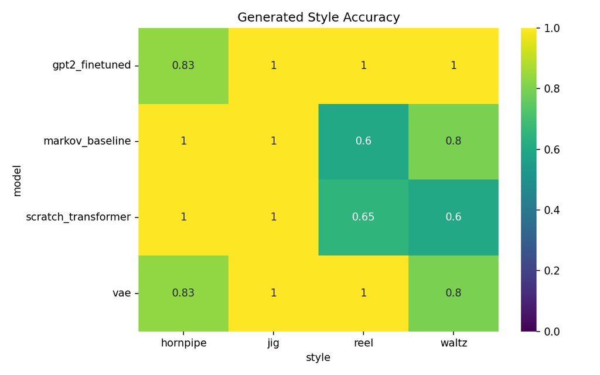

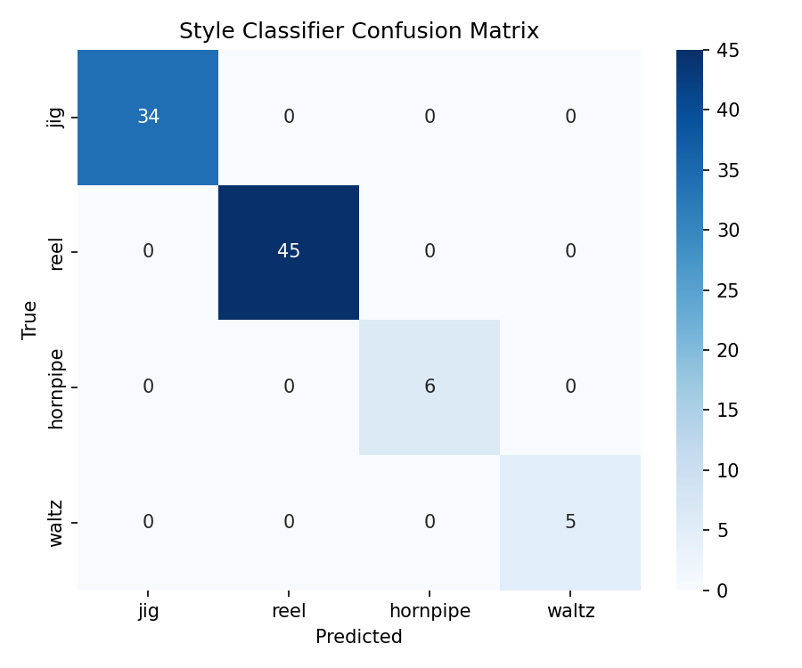

```python
# Left: metric heatmap across models.  Right: confusion matrix of the style classifier (judge).
display(Image("metrics_comparison_heatmap.png"))
display(Image("classifier_confusion_matrix.png"))
```

## 4 Task 2 — Related Work

- **Huang et al. (2018/2019), "Music Transformer"** introduced self-attention for long-term musical structure and conditional continuation/accompaniment — the architectural motivation for our scratch Transformer.
- **Geerlings & Meroño-Peñuela (2020)** fine-tuned GPT-2 to produce *controlled, believable* ABC sequences — direct precedent for our GPT-2 conditional continuation, where the control is the detected style token.
- **Wu et al. (2024), "MelodyT5"** frame symbolic music as score-to-score tasks (including harmonisation-style conditioning) in ABC — related to our style-conditioned generation; data-prep hooks for it remain in the code, though the final run uses the four models above.
- Style/structure-following metrics follow the **Yang & Lerch (2018)** objective-evaluation tradition, extended here with a *classifier-as-judge* for the condition itself.

**How our results compare.** As in the GPT-2-for-ABC work, a pretrained language prior gives the best condition-following; as in the broader literature, no single model dominates — likelihood, condition-accuracy and diversity trade off against each other.

# Summary, Honest Limitations & Generated Samples

**Headline findings.**

- *Task 1:* CharLSTM gives the best held-out likelihood (PPL 2.71) and beats the Markov baseline; MelodyT5 best matches the real distribution (OA 0.302). Likelihood ranking ≠ realism ranking.
- *Task 2:* GPT-2 fine-tuned best obeys the style condition (style acc 0.958, composite 0.879); the scratch Transformer has the lowest perplexity; the VAE is the most diverse. All four beat or match the Markov baseline on the dimension they target.

**Limitations we are explicit about.**

- Published Nottingham scores use different representations/splits, so we treat them as historical context, **not** a direct comparison (see `REPORT_REFERENCES_AND_METRICS.md`).
- We do not compute a clean per-token perplexity for GPT-2 (sub-word tokens) or the VAE.
- TunesFormer / MelodyT5 are **pretrained references**, not models we trained.
- Hornpipe/waltz test sets are small, so their per-style numbers are higher-variance.

**Generated music (submitted files).**

- `symbolic_unconditioned.mid` — best Task 1 sample.
- `symbolic_conditioned.mid` — best Task 2 conditioned continuation.
- Task 2 narrated audio reels (`results/task2/audio_reels/`) play the seed and each model's continuation back-to-back for the human-listening part of the presentation.